# Deep Learning Grundlagen - Modell und Training

[interactive chart not shown]

## Deep Learning Modell

Architektur: Neuronale Netzstruktur

Neuronales Netz = einfache Dartstellung komplexer Rechnung einfacher Bausteine

LinReg mit Basisfunktionen aus LinReg mit Basis aus Linreg mit Basis aus ...

Modell = Architektur mit Satz von Parametern

[figure not shown]

[mehr zu Neuronalen Netzen](https://towardsdatascience.com/a-beginner-friendly-explanation-of-how-neural-networks-work-55064db60df4)

[interactive chart not shown]

[figure not shown]

## Layer

Layer = Level für Lineare Regression

Mehrere Knoten (Perceptronen)

Knoten = gewichtete Summe & Aktivierungsfunktion

[figure not shown]

[interactive chart not shown]

## Aktivierungsfunktion

\mathbf{z_2} = \mathbf{W_2} \mathbf{z_1} + \mathbf{b_2}

\mathbf{z_1} = \mathbf{W_1} \mathbf{x} + \mathbf{b_1}

= \mathbf{W_2} (\mathbf{W_1} \mathbf{x} + \mathbf{b_1}) + \mathbf{b_2}

= \mathbf{W_2} \mathbf{W_1} \mathbf{x} + \mathbf{W_2} \mathbf{b_1} + \mathbf{b_2}

= \mathbf{W_{ges}} \mathbf{x} + \mathbf{b_{ges}}

Wofür Aktivierung?

Ohne Aktivierung: N Layer = 1 Layer

Lineare Kombination  
von Linearkombinationen  
ist eine Linearkombination

Nicht-Lineare Aktivierung  
ermöglicht komplexe Modellierung

z_{1,j} = \sum_{i=1}^{n} c_{1,ij} \cdot x_i

z_2 = \sum_{j=1}^{m} c_{2,j} \cdot z_{1,j}

= \sum_{i=1}^{n} \left( \sum_{j=1}^{m} c_{2,j} \cdot c_{1,ij} \right) \cdot x_i

= \sum_{i=1}^{n} c_{\text{ges}, i} \cdot x_i

= \sum_{j=1}^{m} c_{2,j} \cdot \left( \sum_{i=1}^{n} c_{1,ij} \cdot x_i \right)

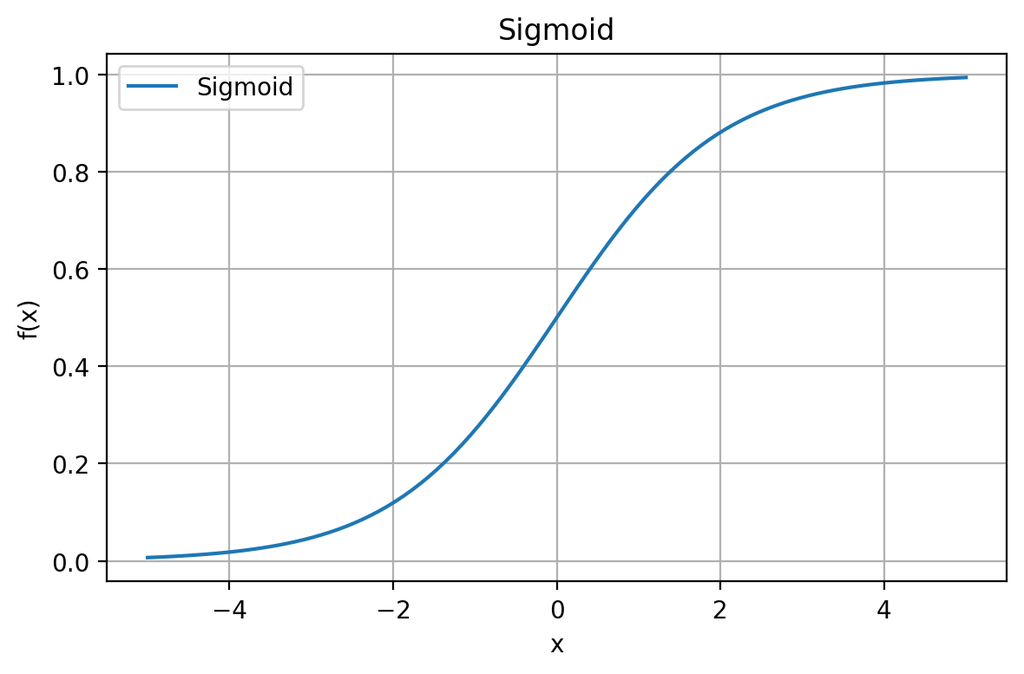

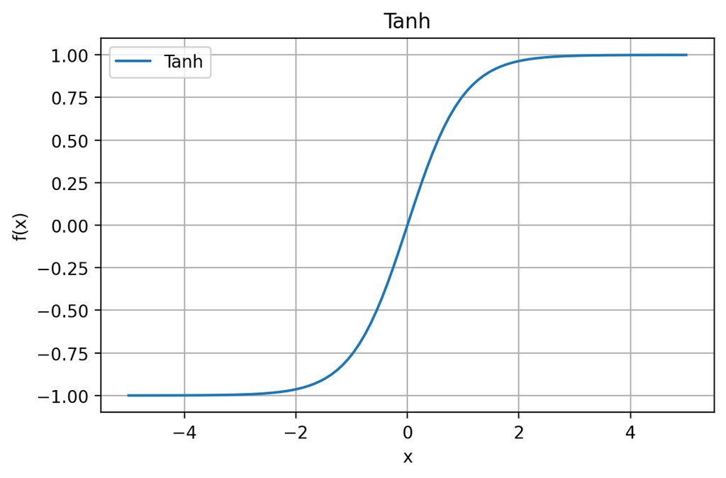

\text{Sigmoid}\\ \sigma(x) = \frac{1}{1 + e^{-x}}

\tanh(x) = \frac{e^x - e^{-x}}{e^x + e^{-x}}

\text{ReLU}(x) = \max(0, x)

[Mehr zu Aktivierungen](https://towardsdatascience.com/everything-you-need-to-know-activation-functions-for-deep-learning-models-ac6f528da604)

[interactive chart not shown]

Wahl der Aktivierung:

- Output: Wertebereich Target
- Hidden: Effizienz (?)

## Aktivierungsfunktion

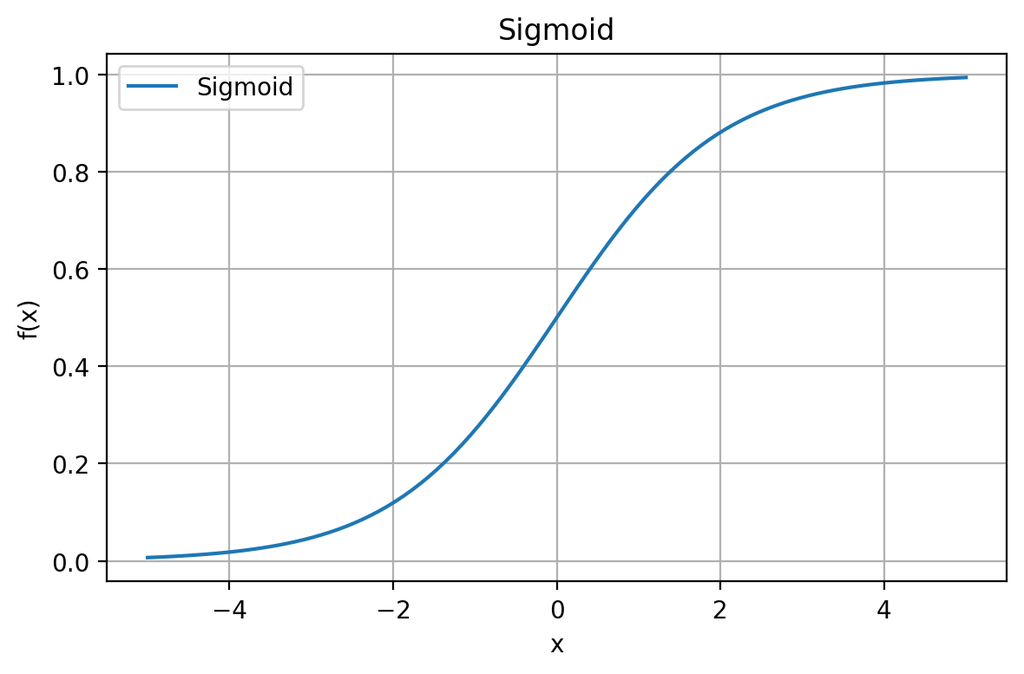

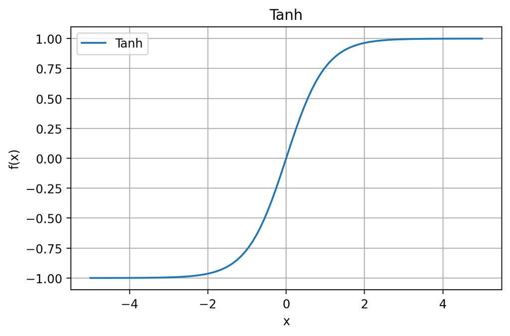

\text{Sigmoid}\\ \sigma(x) = \frac{1}{1 + e^{-x}} \\ \sigma'(x) = \sigma(x)(1-\sigma(x))

\tanh(x) = \frac{e^x - e^{-x}}{e^x + e^{-x}} \\ \tanh'(x) = 1 - \tanh^2(x)

\text{ReLU}(x) = \max(0, x) \\ \text{ReLU}'(x) = \begin{cases} 0 & \text{if } x < 0 \\ 1 & \text{if } x > 0 \end{cases}

Wahl der Aktivierung:

- Output: Wertebereich Target
- Hidden: Effizienz (ReLU)

[Mehr zu Aktivierungen](https://towardsdatascience.com/everything-you-need-to-know-activation-functions-for-deep-learning-models-ac6f528da604)

## Aktivierungsfunktion

\text{ReLU}(x) = \max(0, x) \\ \text{ReLU}'(x) = \begin{cases} 0 & \text{if } x < 0 \\ 1 & \text{if } x > 0 \end{cases}

Dying ReLU:

- Permanent x < 0
- ReLU & Ableitung = 0
- Perceptron lernt nicht
- Wird Unbrauchbar

## Aktivierungsfunktion

\text{ReLU}(x) = \max(0, x) \\ \text{ReLU}'(x) = \begin{cases} 0 & \text{if } x < 0 \\ 1 & \text{if } x > 0 \end{cases}

Dying ReLU:

- Permanent x < 0
- ReLU & Ableitung = 0
- Perceptron lernt nicht
- Wird Unbrauchbar

PReLU, RReLU, ELU, SELU, GELU, Swish, Mish, ReLU6, ...

\text{Leaky ReLU}(x) = \max(\alpha x, x) \\ \text{Leaky ReLU}'(x) = \begin{cases} \alpha & \text{if } x < 0 \\ 1 & \text{if } x > 0 \end{cases}

[figure not shown]

\text{ALReLU}(x) = \begin{cases} x & \text{if } x > 0 \\ |\alpha \cdot x| & \text{if } x < 0 \end{cases} \\ \text{ALReLU}'(x) = \begin{cases} 1 & \text{if } x > 0 \\ -\alpha & \text{if } x < 0 \end{cases}

nützlich bei sehr seltener Aktivierung

## Aktivierungsfunktion

[figure not shown]

[interactive chart not shown]

## Aktivierungsfunktion

## Implementation

|  | Pytorch | Tensorflow |
| --- | --- | --- |
| Eigenschaften | Pythonic, einfache Syntax schnelleres Training dynamischer Berenchnungsgraph höhere Flexibilität | Skalierbar Speichereffizient statisch oder dynamisch |
| Hauptanwendung | Forschung Prototyping | Grossprojekte Produktion |
| Community | Forschung | Industrie |
| Pakete | TorchText, TorchVision, TorchAudio | TF Extended, TF Lite, TF Serving |

[figure not shown]

Beide Frameworks sehr nützlich & weit verbreitet

Mathematik identisch & Aufbau sehr ähnlich

Wahl meist durch Arbeitsumfeld bestimmt

## Architektur entwerfen

1. Aufgabe klar definieren (Klassifikation, Regression, Erkennung, ...)
2. Ein- und Ausgabedimension festlegen (MNIST: In: 784; Out: 10)
3. Geeignete Art von Schichten bestimmen (Linear, Convolutional, ...)
4. Anzahl Schichten und Neuronen pro Schicht festlegen
5. Aktivierungsfunktionen festlegen (Hidden & Output)

Wenn möglich, bereits existierende Architektur / Modelle verwenden

[interactive chart not shown]

## Implementation: Architektur

- MNIST Classifier

```python
from torch import nn
import torch.nn.functional as F

class Classifier(nn.Module):
    def __init__(self):
        super().__init__()





    def forward(self, x):




        return x

model = Classifier()
output = model(data)
```

Pytorch (Meta)

- MNIST Classifier

## Implementation: Architektur

```python
from torch import nn
import torch.nn.functional as F

class Classifier(nn.Module):
    def __init__(self):
        super().__init__()



        self.fc4 = nn.Linear(784, 10)

    def forward(self, x):



        x = self.fc4(x)
        return x

model = Classifier()
output = model(data)
```

Pytorch (Meta)

- MNIST Classifier
- 10 Outputs

## Implementation: Architektur

```python
from torch import nn
import torch.nn.functional as F

class Classifier(nn.Module):
    def __init__(self):
        super().__init__()
        self.fc1 = nn.Linear(784, 64)
        self.fc2 = nn.Linear(64, 64)
        self.fc3 = nn.Linear(64, 64)
        self.fc4 = nn.Linear(64, 10)

    def forward(self, x):
        x = self.fc1(x)
        x = self.fc2(x)
        x = self.fc3(x)
        x = self.fc4(x)
        return x

model = Classifier()
output = model(data)
```

Pytorch (Meta)

- MNIST Classifier
- 10 Outputs
- 3 Hidden Layer

## Implementation: Architektur

```python
from torch import nn
import torch.nn.functional as F

class Classifier(nn.Module):
    def __init__(self):
        super().__init__()
        self.fc1 = nn.Linear(784, 64)
        self.fc2 = nn.Linear(64, 64)
        self.fc3 = nn.Linear(64, 64)
        self.fc4 = nn.Linear(64, 10)

    def forward(self, x):
        x = F.relu(self.fc1(x))
        x = F.relu(self.fc2(x))
        x = F.relu(self.fc3(x))
        x = self.fc4(x)
        return x

model = Classifier()
output = model(data)
```

Pytorch (Meta)

- MNIST Classifier
- 10 Outputs
- 3 Hidden Layer

## Implementation: Architektur

```python
from torch import nn
import torch.nn.functional as F

class Classifier(nn.Module):
    def __init__(self):
        super().__init__()
        self.fc1 = nn.Linear(784, 64)
        self.fc2 = nn.Linear(64, 64)
        self.fc3 = nn.Linear(64, 64)
        self.fc4 = nn.Linear(64, 10)

    def forward(self, x):
        x = F.relu(self.fc1(x))
        x = F.relu(self.fc2(x))
        x = F.relu(self.fc3(x))
        x = F.softmax(self.fc4(x), dim=1)
        return x

model = Classifier()
output = model(data)
```

Pytorch (Meta)

- MNIST Classifier
- 10 Outputs
- 3 Hidden Layer
- Softmax activation

## Implementation: Architektur

```python
from torch import nn
import torch.nn.functional as F

class Classifier(nn.Module):
    def __init__(self):
        super().__init__()
        self.fc1 = nn.Linear(784, 64)
        self.fc2 = nn.Linear(64, 64)
        self.fc3 = nn.Linear(64, 64)
        self.fc4 = nn.Linear(64, 10)

    def forward(self, x):
        x = F.relu(self.fc1(x))
        x = F.relu(self.fc2(x))
        x = F.relu(self.fc3(x))
        x = F.softmax(self.fc4(x), dim=1)
        return x

model = Classifier()
output = model(data)
```

Pytorch (Meta)

```python
import tensorflow as tf
from tensorflow.keras import layers

class Classifier(tf.keras.Model):
    def __init__(self):
        super(Classifier, self).__init__()
        self.fc1 = layers.Dense(64, activation='relu')
        self.fc2 = layers.Dense(64, activation='relu')
        self.fc3 = layers.Dense(64, activation='relu')
        self.fc4 = layers.Dense(10, activation='softmax')

    def call(self, x):
        x = self.fc1(x)
        x = self.fc2(x)
        x = self.fc3(x)
        x = self.fc4(x)
        return x

model = Classifier()
model.build((None, 784))
model(data)
```

Tensorflow (Google)

- MNIST Classifier
- 10 Outputs
- 3 Hidden Layer
- Softmax activation

[interactive chart not shown]

## Implementation: Architektur

```python
import torch.nn as nn

model = nn.Sequential(
    nn.Linear(784, 64),
    nn.ReLU(),
    nn.Linear(64, 64),
    nn.ReLU(),
    nn.Linear(64, 64),
    nn.ReLU(),
    nn.Linear(64, 10),
    nn.Softmax(dim=1)
)

output = model(data)
```

Pytorch (Meta)

```python
from tensorflow.keras import models

model = models.Sequential([
    layers.Dense(64, activation='relu', input_shape=(784,)),
    layers.Dense(64, activation='relu'),
    layers.Dense(64, activation='relu'),
    layers.Dense(10, activation='softmax')
])

model(data)
```

Tensorflow (Google)

[interactive chart not shown]

## Implementation: Architektur

- MNIST Classifier
- 10 Outputs
- 3 Hidden Layer
- Softmax activation

## Trainingsloop

1. Daten laden (batch)
2. Modell anwenden (forward)
3. Loss berechnen
4. Updates berechnen (backward)
5. Update durchfüren

```python
for images, labels in trainloader:
```

```python
    prediction = model(images)
```

```python
    loss = criterion(prediction, labels)
```

```python
    optimizer.zero_grad()
    loss.backward()
```

```python
    optimizer.step()
```

```python
trainloader = DataLoader(trainset, batch_size=256, shuffle=True)
```

[interactive chart not shown]

## Trainingsloop entwerfen

1. Aufgabe klar definieren
2. Lossfunktion bestimmen
3. Berechnungsschritte definieren

[interactive chart not shown]

## Loss Funktion

- Definiert das Ziel des Trainings
- Ziel: Loss minimieren
- erlaubt Vergleich von Modellen
- verschiedene Losses für verschiedene Aufgaben

[interactive chart not shown]

## Loss Funktion

- Mean Squared Error (MSE):  
  mittlerer quadratische Abweichung

MSE = \frac{1}{N} \sum_{i=1}^{N} (y_i - \hat{y}_i)^2

## Loss Funktion

- Mean Squared Error (MSE):  
  mittlerer quadratische Abweichung
- Binäre Cross-Entropy (BCE):  
  vergleich von Wahrscheinlichkeit einer Klasse

MSE = \frac{1}{N} \sum_{i=1}^{N} (y_i - \hat{y}_i)^2

BCE = -\sum_{i=1}^{N} [y_i \log(\hat{y}_i) + (1 - y_i) \log(1 - \hat{y}_i)]

## Loss Funktion

- Mean Squared Error (MSE):  
  mittlerer quadratische Abweichung
- Binäre Cross-Entropy (BCE):  
  vergleich von Wahrscheinlichkeit einer Klasse
- Cross-Entropy (CE):  
  vergleich von Wahrscheinlichkeiten mehrerer Klassen

MSE = \frac{1}{N} \sum_{i=1}^{N} (y_i - \hat{y}_i)^2

BCE = -\sum_{i=1}^{N} [y_i \log(\hat{y}_i) + (1 - y_i) \log(1 - \hat{y}_i)]

CE = -\sum_{i=1}^{N} \sum_{c=1}^{C} y_{ic} \log(\hat{y}_{ic})

mehr zu

[Hintergrund](https://towardsdatascience.com/loss-functions-and-their-use-in-neural-networks-a470e703f1e9)

und

[Varianten](https://towardsdatascience.com/common-loss-functions-in-machine-learning-46af0ffc4d23)

[interactive chart not shown]

## Implementation: Training

- Loss: CrossEntropy

```python
criterion = nn.CrossEntropyLoss()
```

Pytorch

- Loss: CrossEntropy

## Implementation: Training

```python
criterion = nn.CrossEntropyLoss()
optimizer = optim.Adam(model.parameters(), lr=0.003)
```

Pytorch

- Loss: CrossEntropy
- Optimizer: Adam

## Implementation: Training

```python
criterion = nn.CrossEntropyLoss()
optimizer = optim.Adam(model.parameters(), lr=0.003)

for e in range(epochs):
```

Pytorch

- Loss: CrossEntropy
- Optimizer: Adam

## Implementation: Training

Epoche: alle Daten trainieren

```python
criterion = nn.CrossEntropyLoss()
optimizer = optim.Adam(model.parameters(), lr=0.003)

for e in range(epochs):

    for images, labels in trainloader:
```

Pytorch

- Loss: CrossEntropy
- Optimizer: Adam

## Implementation: Training

Batchweise Input & Target

```python
criterion = nn.CrossEntropyLoss()
optimizer = optim.Adam(model.parameters(), lr=0.003)

for e in range(epochs):

    for images, labels in trainloader:
        prediction = model(images)
        loss = criterion(prediction, labels)
```

Pytorch

- Loss: CrossEntropy
- Optimizer: Adam

Forward-Pass

## Implementation: Training

```python
criterion = nn.CrossEntropyLoss()
optimizer = optim.Adam(model.parameters(), lr=0.003)

for e in range(epochs):

    for images, labels in trainloader:
        prediction = model(images)
        loss = criterion(prediction, labels)

        optimizer.zero_grad()
        loss.backward()
```

Pytorch

- Loss: CrossEntropy
- Optimizer: Adam

Backward-Pass

## Implementation: Training

```python
criterion = nn.CrossEntropyLoss()
optimizer = optim.Adam(model.parameters(), lr=0.003)

for e in range(epochs):

    for images, labels in trainloader:
        prediction = model(images)
        loss = criterion(prediction, labels)

        optimizer.zero_grad()
        loss.backward()
        optimizer.step()
```

Pytorch

- Loss: CrossEntropy
- Optimizer: Adam

Update

## Implementation: Training

```python
criterion = nn.CrossEntropyLoss()
optimizer = optim.Adam(model.parameters(), lr=0.003)

for e in range(epochs):
    running_loss = 0
    for images, labels in trainloader:
        prediction = model(images)
        loss = criterion(prediction, labels)

        optimizer.zero_grad()
        loss.backward()
        optimizer.step()

        running_loss += loss.item()
```

Pytorch

- Loss: CrossEntropy
- Optimizer: Adam

## Implementation: Training

```python
criterion = nn.CrossEntropyLoss()
optimizer = optim.Adam(model.parameters(), lr=0.003)

for e in range(epochs):
    running_loss = 0
    for images, labels in trainloader:
        prediction = model(images)
        loss = criterion(prediction, labels)

        optimizer.zero_grad()
        loss.backward()
        optimizer.step()

        running_loss += loss.item()
```

Pytorch

- Loss: CrossEntropy
- Optimizer: Adam

```python
model.compile(optimizer=optimizers.Adam(learning_rate=0.003),
              loss='sparse_categorical_crossentropy',
              metrics=['accuracy'])

history = model.fit(train_images, train_labels, epochs=1, batch_size=64)

print(f'Training loss: {history.history["loss"][0]}')
```

Tensorflow

[interactive chart not shown]

## Implementation: Training

## Update

Ableitung der Kosten -> Richtung für Verbesserung -> Update

\theta \leftarrow \theta - \alpha \cdot \frac{\partial \text{Loss}}{\partial \theta}

Gradient Descent

\text{Lernrate } \alpha

## Update

[figure not shown]

\theta \leftarrow \theta - \alpha \cdot \frac{\partial \text{Loss}}{\partial \theta}

\text{Lernrate } \alpha

Gradient Descent

Ableitung der Kosten -> Richtung für Verbesserung -> Update

## Update

[figure not shown]

\theta \leftarrow \theta - \alpha \cdot \frac{\partial \text{Loss}}{\partial \theta}

\text{Lernrate } \alpha

[figure not shown]

[interactive chart not shown]

Gradient Descent

Ableitung der Kosten -> Richtung für Verbesserung -> Update

## Update

[figure not shown]

\theta \leftarrow \theta - \alpha \cdot \frac{\partial \text{Loss}}{\partial \theta}

\text{Lernrate } \alpha

[figure not shown]

[interactive chart not shown]

Gradient Descent

Ableitung der Kosten -> Richtung für Verbesserung -> Update

## Optimizer

\theta \leftarrow \theta - \alpha \cdot \frac{\partial \text{Loss}}{\partial \theta}

[figure not shown]

Loss = \sum\limits_i (y_i - \hat{y}_i)^2 \\ \text{Forward: }\hat{y} = f(x)

x \text{: Input Daten} \\ y \text{: Ziel Daten} \\ \hat{y} \text{: Vorhersage} \\ f \text{: Modell} \\ \theta \text{: Parameter}

[interactive chart not shown]

Gradient Descent

## Optimizer

\theta \leftarrow \theta - \alpha \cdot \frac{\partial \text{Loss}}{\partial \theta}

Loss = \sum\limits_i (y_i - \hat{y}_i)^2 \\ \text{Forward: }\hat{y} = f(x) = a(z) = a(b + w \cdot x) \\~\\

b \text{: Bias} \\ w \text{: Gewichte} \\ a \text{: Aktivierung}

[figure not shown]

[interactive chart not shown]

Gradient Descent

## Optimizer

\theta \leftarrow \theta - \alpha \cdot \frac{\partial \text{Loss}}{\partial \theta}

Loss = \sum\limits_i (y_i - \hat{y}_i)^2 \\ \text{Forward: }\hat{y} = f(x) = a(z) = a(b + w \cdot x) \\~\\ \text{Backward: }\frac{\partial Loss}{\partial b}

[figure not shown]

Gradient Descent

## Optimizer

\theta \leftarrow \theta - \alpha \cdot \frac{\partial \text{Loss}}{\partial \theta}

Loss = \sum\limits_i (y_i - \hat{y}_i)^2 \\ \text{Forward: }\hat{y} = f(x) = a(z) = a(b + w \cdot x) \\~\\ \text{Backward: }\frac{\partial Loss}{\partial b} = \frac{\partial Loss}{\partial \hat{y}_i} \cdot \frac{\partial \hat{y}_i}{\partial a} \cdot \frac{\partial a}{\partial z} \cdot \frac{\partial z}{\partial b} \\~\\

[figure not shown]

Gradient Descent

## Optimizer

\theta \leftarrow \theta - \alpha \cdot \frac{\partial \text{Loss}}{\partial \theta}

Loss = \sum\limits_i (y_i - \hat{y}_i)^2 \\ \text{Forward: }\hat{y} = f(x) = a(z) = a(b + w \cdot x) \\~\\ \text{Backward: }\frac{\partial Loss}{\partial b} = \frac{\partial Loss}{\partial \hat{y}_i} \cdot \frac{\partial \hat{y}_i}{\partial a} \cdot \frac{\partial a}{\partial z} \cdot \frac{\partial z}{\partial b} \\~\\ = \sum\limits_i 2(y_i - \hat{y}_i) \cdot 1 \cdot \frac{\partial a}{\partial z} \cdot 1

[figure not shown]

[interactive chart not shown]

Gradient Descent

## Optimizer

\theta \leftarrow \theta - \alpha \cdot \frac{\partial \text{Loss}}{\partial \theta}

Loss = \sum\limits_i (y_i - \hat{y}_i)^2 \\ \text{Forward: }\hat{y} = f(x) = a(z) = a(b + w \cdot x) \\~\\ \text{Backward: }\frac{\partial Loss}{\partial b} = \frac{\partial Loss}{\partial a} \cdot \frac{\partial a}{\partial z} \cdot \frac{\partial z}{\partial b} \\~\\ = \sum\limits_i 2(y_i - \hat{y}_i) \cdot \frac{\partial a}{\partial z}

[figure not shown]

Gradient Descent

## Optimizer

\theta \leftarrow \theta - \alpha \cdot \frac{\partial \text{Loss}}{\partial \theta}

Loss = \sum\limits_i (y_i - \hat{y}_i)^2 \\ \text{Forward: }{\color{red} \hat{y}_i = f({\color{orange}x_i}) = {\color{red}a_1(z_1({\color{orange}x_i}))} = {\color{red} a_1(b_1 + w_1 \cdot {\color{orange}x_i})}} \\~\\ \text{Backward: }\frac{\partial Loss}{\partial b_1} = \frac{\partial Loss}{\partial a_1} \cdot {\color{red} \frac{\partial a_1}{\partial z_1} \cdot \frac{\partial z_1}{\partial b_1} } \\~\\ = \sum\limits_i 2(y_i - \hat{y}_i) {\color{red} \frac{\partial a_1}{\partial z_1} }

[figure not shown]

[interactive chart not shown]

Gradient Descent

## Optimizer

\theta \leftarrow \theta - \alpha \cdot \frac{\partial \text{Loss}}{\partial \theta}

Loss = \sum\limits_i (y_i - \hat{y}_i)^2 \\ \text{Forward: }{\color{cyan} \hat{y}_i = f({\color{orange}x_i}) = {\color{cyan}a_2(z_2({\color{red}a_1(z_1({\color{orange}x_i}))}))} = {\color{cyan} a_2(b_2 + w_2 \cdot {\color{red} a_1(b_1 + w_1 \cdot {\color{orange}x_i})})}} \\~\\ \text{Backward: }\frac{\partial Loss}{\partial b_1} = \frac{\partial Loss}{\partial a_2} \cdot {\color{cyan} \frac{\partial a_2}{\partial z_2} \cdot \frac{\partial z_2}{\partial a_1} \cdot } {\color{red} \frac{\partial a_1}{\partial z_1} \cdot \frac{\partial z_1}{\partial b_1} } \\~\\ = \sum\limits_i 2(y_i - \hat{y}_i) \cdot{\color{cyan} \frac{\partial a_2}{\partial z_2} \cdot w_2 \cdot } {\color{red} \frac{\partial a_1}{\partial z_1} }

[figure not shown]

[interactive chart not shown]

Gradient Descent

## Optimizer

\theta \leftarrow \theta - \alpha \cdot \frac{\partial \text{Loss}}{\partial \theta}

Loss = \sum\limits_i (y_i - \hat{y}_i)^2 \\ \text{Forward: }{\color{lightgreen} \hat{y}_i = f({\color{orange}x_i}) = a_3(z_3({\color{cyan}a_2(z_2({\color{red}a_1(z_1({\color{orange}x_i}))})) })) = a_3(b_3 + w_3 \cdot {\color{cyan} a_2(b_2 + w_2 \cdot {\color{red} a_1(b_1 + w_1 \cdot {\color{orange}x_i})})})} \\~\\ \text{Backward: }\frac{\partial Loss}{\partial b_1} = \frac{\partial Loss}{\partial a_3} \cdot {\color{lightgreen} \frac{\partial a_3}{\partial z_3} \cdot \frac{\partial z_3}{\partial a_2} \cdot } {\color{cyan} \frac{\partial a_2}{\partial z_2} \cdot \frac{\partial z_2}{\partial a_1} \cdot } {\color{red} \frac{\partial a_1}{\partial z_1} \cdot \frac{\partial z_1}{\partial b_1} } \\~\\ = \sum\limits_i 2(y_i - \hat{y}_i) \cdot {\color{lightgreen} \frac{\partial a_3}{\partial z_3} \cdot w_3 \cdot } {\color{cyan} \frac{\partial a_2}{\partial z_2} \cdot w_2 \cdot } {\color{red} \frac{\partial a_1}{\partial z_1} }

[figure not shown]

[interactive chart not shown]

Gradient Descent

## Optimizer

Berechnet Ableitung

für jedes Update

mit gesamten Datensatz

folgt exakt steilstem Abstieg

Bei Millionen von Daten

sehr rechenintensiv...

\theta \leftarrow \theta - \alpha \cdot \frac{\partial \text{Loss}}{\partial \theta}

\frac{\partial \text{Loss}}{\partial \theta}

Gradient Descent

## Optimizer

Gradient Descent

Berechnet Ableitung

für jedes Update

mit gesamten Datensatz

folgt exakt steilstem Abstieg

Bei Millionen von Daten

sehr rechenintensiv...

\theta \leftarrow \theta - \alpha \cdot \frac{\partial \text{Loss}}{\partial \theta}

\frac{\partial \text{Loss}}{\partial \theta}

Stochastic Gradient Descent (SGD)

Zerlegt Datensatz in Batches

Update nach jeder Batch

folgt Schätzung des steilsten Abstiegs

Forschritt kann Schwanken

Schnelle Konvergenz  
dank schneller Rechnung

## Optimizer

\theta \leftarrow \theta - \alpha \cdot \frac{\partial \text{Loss}}{\partial \theta}

[figure not shown]

[interactive chart not shown]

Gradient Descent

## Optimizer

SGD

\theta \leftarrow \theta - \alpha \cdot \frac{\partial \text{Loss}}{\partial \theta}

[figure not shown]

v \leftarrow \beta \cdot v + \alpha \cdot \frac{\partial \text{Loss}}{\partial \theta} \\ \theta \leftarrow \theta - v

Momentum

[mehr zu](https://towardsdatascience.com/optimizers-for-training-neural-network-59450d71caf6)

[Optimizern](https://towardsdatascience.com/optimizers-for-training-neural-network-59450d71caf6)

[interactive chart not shown]

## Model & Trainingsloop

Hands-On: MNIST Classifier

Bearbeiten Sie [dieses Notebook](https://colab.research.google.com/drive/1GLso7wqttpFdk7VkHiamI8r7O4MvXvsb?usp=sharing)

- Erstellen Sie einen MNIST Classifier
- Definieren Sie die Trainingsloop
- Testen sie die Trainingsloop ueber zwei Epochen

Die Lösung finden Sie in [diesem Notebook](https://colab.research.google.com/drive/1PtMcVfqDN0HTRuSnEyPOvOP4ahT6NcVQ?usp=sharing)

[interactive chart not shown]